# Cox 迴歸分析報告

性別與肺癌病人死亡事件時間的關聯｜完整 R 程式碼與結果

## 重點摘要（Executive Summary）

- **資料與選模：**228 位病人、165 個死亡事件；有追蹤時間與右設限，採 Cox。
- **主要結果：**女性相對男性 HR＝0.588，95% CI 0.424–0.816。
- **診斷：**Schoenfeld 檢定 p＝0.091，可暫作初步分析；圖中時間趨勢列為後續確認方向。
- **區辨能力：**原資料 Harrell C＝0.579；此為未經驗證的表觀區辨能力，不是個人預測準確率。

## 研究目的

以 `survival::lung` 示範，研究女性相對男性的死亡事件率是否不同。本報告先使用只含性別的 Cox 比例風險模型，未調整年齡等其他變數；結果解釋為關聯。

## 資料與變數介紹

資料為 NCCTG 肺癌資料，每列是一位病人的追蹤紀錄。時間單位為天，原始事件編碼及性別編碼先依資料字典確認，再轉換。

```r
# 載入套件與內建資料；若缺套件，先 install.packages("survival")。
library(survival)
raw_data <- survival::lung

variable_info <- data.frame(
  變數 = c("time", "status", "sex", "event"),
  角色 = c("追蹤時間", "原始狀態", "主要解釋變數", "建模事件欄"),
  說明 = c("天", "1=設限、2=死亡", "1=男性、2=女性", "0=設限、1=死亡")
)
knitr::kable(variable_info, caption = "本次分析使用的變數")
```

本次分析使用的變數

| 變數 | 角色 | 說明 |
| --- | --- | --- |
| time | 追蹤時間 | 天 |
| status | 原始狀態 | 1=設限、2=死亡 |
| sex | 主要解釋變數 | 1=男性、2=女性 |
| event | 建模事件欄 | 0=設限、1=死亡 |

### 前處理與缺失檢查

保留原始資料，另建立事件欄與性別因子。只檢查本次模型使用的欄位，不因其他未使用欄位缺失而排除病人。

```r
stopifnot(all(na.omit(raw_data$status) %in% c(1, 2)))
stopifnot(all(na.omit(raw_data$sex) %in% c(1, 2)))
d <- raw_data
d$event <- as.integer(d$status == 2)
d$sex <- factor(d$sex, levels = c(1, 2), labels = c("男性", "女性"))

missing <- colSums(is.na(d[c("time", "event", "sex")]))
knitr::kable(data.frame(欄位 = names(missing), 缺失數 = unname(missing)))
```

| 欄位 | 缺失數 |
| --- | --- |
| time | 0 |
| event | 0 |
| sex | 0 |

```r
# 此範例的分析欄位應完整；若換自備資料有缺失，先決定處理策略。
stopifnot(!anyNA(d[c("time", "event", "sex")]))
stopifnot(all(d$event %in% c(0, 1)), all(d$time > 0))
knitr::kable(data.frame(
  原始列數 = nrow(raw_data), 分析列數 = nrow(d),
  死亡事件數 = sum(d$event), 設限數 = sum(d$event == 0)
))
```

| 原始列數 | 分析列數 | 死亡事件數 | 設限數 |
| --- | --- | --- | --- |
| 228 | 228 | 165 | 63 |

## 模型選擇與設定

**為什麼使用 Cox？**本研究關心的是死亡多久發生，而且部分病人追蹤結束時仍未發生事件；Cox 能保留時間與右設限資訊。只分析死亡與否會忽略追蹤時間，直接對天數做一般迴歸也不適合這些設限紀錄。男性為參考組，使用 Efron 處理同時發生的事件，提供 95% Wald 信賴區間。

h(t ∣ sex) = h<sub>0</sub>(t) exp{β I(sex = 女性)}

```r
fit <- coxph(Surv(time, event) ~ sex, data = d,
             ties = "efron", x = TRUE, y = TRUE, na.action = na.fail)
summary(fit)
```

```
Call:
coxph(formula = Surv(time, event) ~ sex, data = d, na.action = na.fail,
    ties = "efron", x = TRUE, y = TRUE)

  n= 228, number of events= 165

           coef exp(coef) se(coef)      z Pr(>|z|)
sex女性 -0.5310    0.5880   0.1672 -3.176  0.00149 **
---
Signif. codes:  0 '***' 0.001 '**' 0.01 '*' 0.05 '.' 0.1 ' ' 1

        exp(coef) exp(-coef) lower .95 upper .95
sex女性     0.588      1.701    0.4237     0.816

Concordance= 0.579  (se = 0.021 )
Likelihood ratio test= 10.63  on 1 df,   p=0.001
Wald test            = 10.09  on 1 df,   p=0.001
Score (logrank) test = 10.33  on 1 df,   p=0.001
```

## 分析結果與檢定

性別係數的 Wald 檢定檢查係數是否為 0，等價於女性相對男性的 HR 是否為 1。這項檢定與後面的比例風險假設檢定，回答不同問題。

```r
sm <- summary(fit)
beta <- unname(coef(fit)[1])
se <- sqrt(vcov(fit)[1, 1])
z <- beta / se
p_effect <- 2 * pnorm(-abs(z))
result <- data.frame(
  比較 = "女性相對男性", HR = exp(beta),
  CI下限 = exp(beta - qnorm(.975) * se),
  CI上限 = exp(beta + qnorm(.975) * se),
  Wald_Z = z, p值 = p_effect
)
knitr::kable(result, digits = 4, caption = "性別的 HR、95% CI 與 Wald 檢定")
```

性別的 HR、95% CI 與 Wald 檢定

| 比較 | HR | CI下限 | CI上限 | Wald_Z | p值 |
| --- | --- | --- | --- | --- | --- |
| 女性相對男性 | 0.588 | 0.4237 | 0.816 | -3.1764 | 0.0015 |

女性相對男性的 HR 為 **0.588**，95% CI 為 **0.424–0.816**， Wald p＝**0.00149**。本資料中，女性與較低死亡瞬時事件率有關；HR 不是死亡機率比，也不表示存活時間直接增加相同比例。

### 未調整的 Kaplan–Meier 曲線與風險人數

KM 依性別直接估計存活曲線，不依賴 Cox 的 PH 假設；下方 At-risk table 是各時間點前仍在追蹤、尚未死亡的人數。這是同一示範的描述性補充，不另行選擇其他主模型。

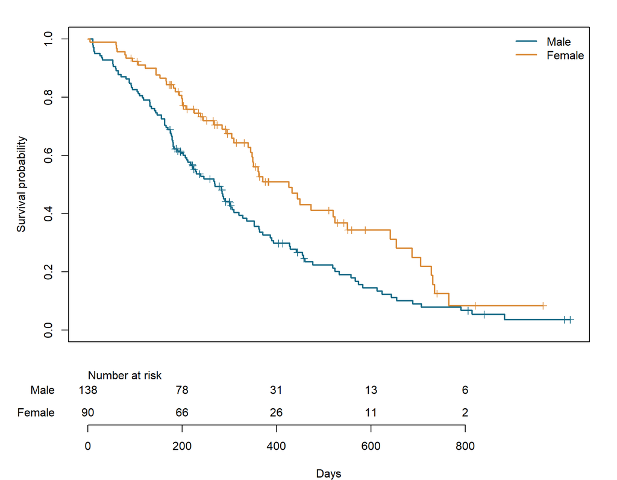

按性別分組的 KM 存活曲線與 At-risk table

```r
km <- survfit(Surv(time,event)~sex,data=d)
risk_times <- c(0,200,400,600,800)
risk_matrix <- sapply(risk_times,function(t)
  vapply(levels(d$sex),function(g) sum(d$sex==g & d$time>=t),integer(1)))
rownames(risk_matrix) <- c("Male","Female")
colnames(risk_matrix) <- risk_times
layout(matrix(1:2,ncol=1),heights=c(4,1.4))
par(mar=c(1,5,2,2))
plot(km,col=c("#176b87","#da8b38"),lwd=2,mark.time=TRUE,
     xlim=c(0,max(d$time)),xlab="",ylab="Survival probability",xaxt="n")
legend("topright",legend=c("Male","Female"),col=c("#176b87","#da8b38"),lwd=2,bty="n")
par(mar=c(4,5,1,2))
plot(NA,xlim=c(0,max(d$time)),ylim=c(.5,2.8),xlab="Days",ylab="",yaxt="n",xaxt="n",bty="n")
axis(1,at=risk_times);axis(2,at=c(2,1),labels=c("Male","Female"),las=1,tick=FALSE)
text(0,2.65,"Number at risk",adj=0)
for(i in 1:2) text(risk_times,3-i,risk_matrix[i,])
```

```r
layout(1)
```

女性的 KM 曲線多數追蹤時間高於男性，與較低事件率的模型方向一致。後段在風險人數減少，尤其接近追蹤末端時曲線較不穩定，解讀時應一併看人數。

```r
km_summary <- summary(km,times=c(200,400,600,800),data.frame=TRUE)
km_table <- data.frame(性別=sub("sex=","",km_summary$strata),天數=km_summary$time,
  在風險人數=km_summary$n.risk,存活機率=km_summary$surv,
  CI下限=km_summary$lower,CI上限=km_summary$upper)
knitr::kable(km_table,digits=3,caption="指定時間點的 KM 存活估計與95% CI")
```

指定時間點的 KM 存活估計與95% CI

| 性別 | 天數 | 在風險人數 | 存活機率 | CI下限 | CI上限 |
| --- | --- | --- | --- | --- | --- |
| 男性 | 200 | 78 | 0.607 | 0.531 | 0.695 |
| 男性 | 400 | 31 | 0.298 | 0.225 | 0.394 |
| 男性 | 600 | 13 | 0.145 | 0.090 | 0.234 |
| 男性 | 800 | 6 | 0.067 | 0.031 | 0.143 |
| 女性 | 200 | 66 | 0.795 | 0.714 | 0.884 |
| 女性 | 400 | 26 | 0.509 | 0.403 | 0.642 |
| 女性 | 600 | 11 | 0.343 | 0.239 | 0.493 |
| 女性 | 800 | 2 | 0.083 | 0.026 | 0.270 |

```r
stopifnot(all(risk_matrix[,1]==as.integer(table(d$sex))))
```

### HR 森林圖

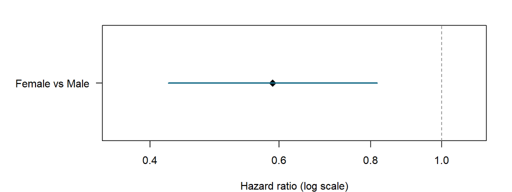

女性相對男性的 HR 與95% Wald CI（對數刻度）

```r
par(mar=c(4,8,2,2))
plot(result$HR,1,log="x",xlim=range(c(result$CI下限,result$CI上限,1)) * c(.85,1.1),
     ylim=c(.5,1.5),yaxt="n",ylab="",xlab="Hazard ratio (log scale)",pch=18,cex=1.5)
segments(result$CI下限,1,result$CI上限,1,lwd=2,col="#176b87")
abline(v=1,lty=2,col="gray50")
axis(2,at=1,labels="Female vs Male",las=1)
```

點估計與區間位於 HR＝1 左側，表示女性相對男性的事件率較低。本例只有一個效果，森林圖主要作視覺示範，不會為了增加圖上的項目而更動模型。

### C-index：區辨能力

```r
con <- concordance(fit)
c_index <- unname(con$concordance)
c_se <- sqrt(unname(con$var))
knitr::kable(data.frame(Harrell_C=c_index,SE=c_se,
  CI下限=max(0,c_index-qnorm(.975)*c_se),CI上限=min(1,c_index+qnorm(.975)*c_se)),
  digits=3,caption="原分析資料的表觀 C-index 與近似95% CI")
```

原分析資料的表觀 C-index 與近似95% CI

| Harrell_C | SE | CI下限 | CI上限 |
| --- | --- | --- | --- |
| 0.579 | 0.021 | 0.538 | 0.619 |

本例 C-index＝**0.579**，表示在可比較的病人配對中，模型對較早發生事件者的風險排序能力有限；只有性別這個二元預測變數，會產生許多相同風險分數。本指標衡量排序區辨，不衡量預測機率校準，也不是「正確預測病人」的百分比。此處使用配適的同一資料，屬表觀表現；若目標是預測，還需依規劃做內部／外部驗證。本報告未執行這些驗證。

### 模型估計的存活曲線

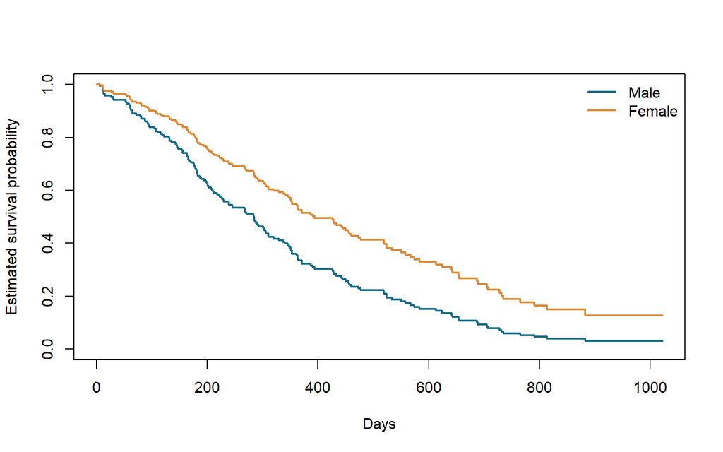

只含性別之 Cox 模型估計存活曲線

```r
new_d <- data.frame(sex = factor(c("男性", "女性"), levels = levels(d$sex)))
curves <- survfit(fit, newdata = new_d)
plot(curves, col = c("#176b87", "#da8b38"), lwd = 2,
     xlab = "Days", ylab = "Estimated survival probability")
legend("topright", legend = c("Male", "Female"),
       col = c("#176b87", "#da8b38"), lwd = 2, bty = "n")
```

## 模型診斷：Schoenfeld 殘差

用 `cox.zph()` 進行比例風險假設檢查：檢定是否有證據顯示效果隨時間改變。

```r
ph <- cox.zph(fit)
knitr::kable(as.data.frame(ph$table), digits = 4,
             caption = "Schoenfeld 殘差的比例風險假設檢定")
```

Schoenfeld 殘差的比例風險假設檢定

|  | chisq | df | p |
| --- | --- | --- | --- |
| sex | 2.8632 | 1 | 0.0906 |
| GLOBAL | 2.8632 | 1 | 0.0906 |

```r
p_ph <- unname(ph$table["GLOBAL", "p"])
```

全域檢定 p＝**0.091**。以 0.05 為顯著水準，未發現顯著違反比例風險假設的證據。

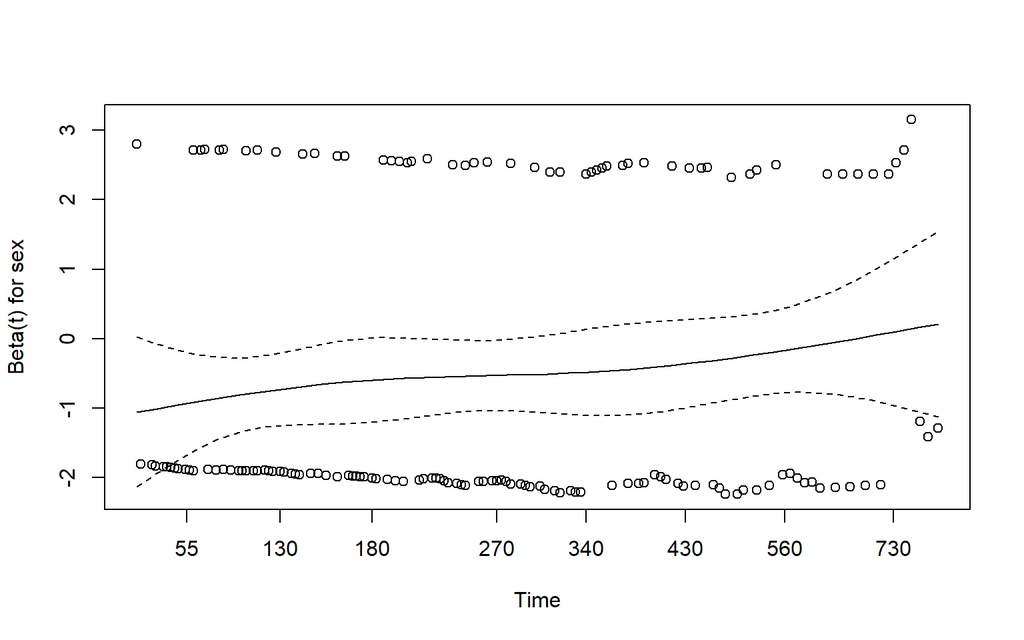

縮放 Schoenfeld 殘差診斷圖：估計性別效果隨時間的變化

```r
plot(ph)
```

**圖形判讀：**性別效果的平滑曲線由早期較負的值逐漸上升，後段接近 0，提示女性較低事件率的關聯可能隨時間減弱。追蹤後段的不確定帶較寬，末端估計需較審慎判讀。

**合併判讀：**Schoenfeld 殘差檢定 p＝0.091，未達 0.05，可暫以此 Cox 模型進行分析。圖中的上升趨勢值得進一步確認；若要更完整評估固定 HR 的適切性，可依研究規劃加入時間變動效果作敏感度分析。本例尚未執行這項延伸。

## 結論與限制

本例共分析 **228** 位病人、**165** 個死亡事件。 女性相對男性的死亡 HR 小於 1，Wald 檢定顯示性別與事件率有統計關聯。 比例風險檢定 p＝0.091，未發現顯著違反 PH 的證據，可暫以此模型作初步分析。Schoenfeld 圖顯示性別效果隨時間上升、後段不確定性較大；進一步可評估時間變動效果，確認固定 HR 摘要是否合適。

本例未調整其他共變數，結論限於關聯；設限機制的合理性需結合研究設計與追蹤情形評估。

## 來源與執行環境

- 資料與編碼：[survival::lung 文件](https://stat.ethz.ch/R-manual/R-devel/library/survival/html/lung.html)
- PH 診斷：[cox.zph 文件](https://stat.ethz.ch/R-manual/R-devel/library/survival/html/cox.zph.html)
- 方法另參考先前課堂教材。

## 摘要計算程式

摘要與下方主分析採同一資料與設定；以下保留產生摘要數值的程式。

```r
summary_data <- survival::lung
summary_data$event <- as.integer(summary_data$status == 2)
summary_data$sex <- factor(summary_data$sex, levels=c(1,2), labels=c("男性","女性"))
summary_fit <- survival::coxph(survival::Surv(time,event)~sex,
                              data=summary_data,ties="efron",x=TRUE,y=TRUE)
summary_sm <- summary(summary_fit)
summary_hr <- summary_sm$conf.int[1,]
summary_ph <- survival::cox.zph(summary_fit)$table["GLOBAL","p"]
summary_c <- survival::concordance(summary_fit)$concordance
```